# Tvyal Newsletter

Aghasi Tavadyan

2024-04-26

*English summary below.*

Հարգելի գործընկեր,

Հուսով եմ լավ եք: Ներկայացնում եմ այս շաբաթվա վերլուծությունները և աշխատանքները.

**ՈՒՇԱԴՐՈՒԹՅՈՒՆ․ ՄԵՆՔ !!PODCAST!! ՈՒՆԵՆՔ․ ՄԱՆՐԱՄԱՍՆԵՐԸ ՆԵՐՔԵՎՈՒՄ**

## 💼🚚✈️ Ծառայությունների ապրանքաշրջանառության փոփոխությունը

Հայաստանի ծառայությունների արտահանման և ներմուծման ուսումնասիրության համար օգտագործվել է ՀՀ վճարային հաշվեկշռի եռամսյակային տվյալները: Տվյալների վերլուծությունը ցույց է տվել, որ 2020 թվականին ծառայությունների առևտրաշրջանառությունը զգալի անկում է ունեցել՝ հիմնականում պայմանավորված զբոսաշրջային ծառայությունների արտահանման և ներմուծման նվազմամբ։ 2021 և հատկապես 2022թ. թվականին առկա են ծառայությունների առևտրաշրջանառության վերականգնողական աճ, որը շարունակվել է մինչև 2023 թվականի չորրորդ եռամսյակը։ 2023 թվականի չորրդր եռամսյակում արդեն գրեթե բոլոր ծառայությունների արտահանումը կճատվել է։

**Գծապատկեր 1.**

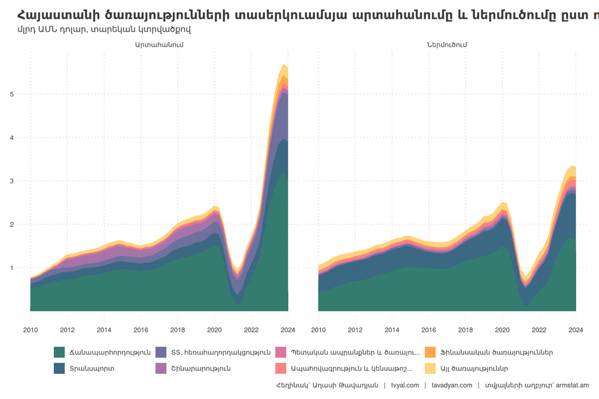

Ծառայությունների և ներմուծումը և արտահանումը 2023-ի 4-րդ եռամսյակից անկում են ապրել։

Ինչպես երևում է, Հայաստանի 2023 թվականի ծառայությունների արտահանման հիմնական ոլորտներն են եղել ճանապարհորդությունը և ՏՏ ծառայությունները՝ համապատասխանաբար 3 մլրդ և 1 մլրդ դոլարի, որոնք կազմել են 2023 թվականի ծառայությունների արտահանման համապատասխանաբար 53.5 և 19.1 տոկոսը։ Այս ծառայությունների 2022-23 թվականների աճը ապահովել է նաև մեր տնտեսական աճի զգալի հատվածը։ Ծառայությունների կրճատման տենդենցը, որը կարող է շարունակվել 2024 թվականին, մտահոգիչ է հատկապես ընթացիկ հաշվեկշռի և բյուջեի մասին oրենքով պլանավորված 7 տոկոս տնտեսական աճի ապահովման տեսանկյունից։

**Աղյուսակ 1.**

Հայաստանի ծառայությունների արտահանման միտումը 2018-2023

միլիոն ԱՄՆ դոլար

| Ծառայության անվանումը |  | 2018 | 2019 | 2020 | 2021 | 2022 | 2023 | 2023 Q4* |
| --- | --- | --- | --- | --- | --- | --- | --- | --- |
| Ճանապարհորդություն | մլն $ աճ | 1 329.0 10.4% | 1 528.0 15.0% | 287.3 -81.2% | 784.2 172.9% | 2 439.1 211.0% | 3 009.3 23.4% | -42.6% |
| ՏՏ, հեռահաղորդակցություն | մլն $ աճ | 235.8 11.4% | 261.7 11.0% | 328.5 25.5% | 382.4 16.4% | 711.4 86.0% | 1 074.0 51.0% | -8.7% |
| Տրանսպորտ | մլն $ աճ | 256.3 10.7% | 275.4 7.4% | 232.4 -15.6% | 304.4 31.0% | 585.2 92.2% | 895.8 53.1% | 70.4% |
| Շինարարություն | մլն $ աճ | 191.1 -7.7% | 178.1 -6.8% | 77.7 -56.4% | 86.1 10.9% | 104.2 21.0% | 87.5 -16.1% | -19.2% |
| Այլ գործնական ծառայություններ | մլն $ աճ | 45.9 -6.1% | 43.2 -5.7% | 42.4 -2.0% | 36.2 -14.6% | 56.0 54.7% | 65.6 17.2% | -7.5% |
| Այլ կողմերին պատկանող նյութական ռեսու… | մլն $ աճ | 35.5 67.1% | 27.2 -23.3% | 36.8 35.0% | 41.0 11.6% | 111.0 170.3% | 200.2 80.5% | -38.1% |
| Պետական ապրանքներ և ծառայություններ | մլն $ աճ | 44.5 7.9% | 45.5 2.2% | 33.2 -27.0% | 37.3 12.4% | 38.2 2.3% | 34.2 -10.5% | -7.5% |
| Ապահովագրություն և կենսաթոշակային ծառ… | մլն $ աճ | 28.0 8.3% | 31.5 12.2% | 28.7 -8.8% | 34.7 21.0% | 61.1 76.1% | 77.0 26.0% | 18.8% |
| Ֆինանսական ծառայություններ | մլն $ աճ | 14.4 45.9% | 19.0 32.2% | 19.1 0.5% | 14.2 -26.0% | 198.3 1 301.1% | 158.9 -19.8% | 0.3% |
| Անձնական, մշակութային և զվարճանքի ծառ… | մլն $ աճ | 19.0 0.6% | 19.3 1.8% | 10.3 -46.5% | 11.1 7.7% | 11.4 2.5% | 11.7 2.1% | -6.5% |
| Տեխնիկական սպասարկման և վերանորոգման … | մլն $ աճ | 2.8 -0.1% | 4.7 72.5% | 3.0 -37.6% | 3.5 19.1% | 4.5 26.9% | 5.2 15.8% | -2.5% |

* 2023 Q4 - 2023 թվականի չորրորդ եռամսյակի հարաբերակցությունը երրորդ եռամսյակին  
Author: Aghasi Tavadyan | tvyal.com | tavadyan.com | Data Source: armstat.am

Ինչպես երևում է առաջին աղյուսակից 2023 թվականի չորրորդ եռամսյակում կրճատման միտում ունեն բոլոր ծառայությունների արտահանումը, բացառությամբ տրանսպորտային և կենսաթոշակային ծառայությունների։ Ֆինանսկան ծառայությունները 2023 թվականի 4-րդ եամսյակում չնչին աճ են ցուցադրել՝ չնայած տարվա կտրվածքով ֆինանսական ծառայությունները կրճատվել են 19.8 տոկոսով։

Նշենք նաև, որ 2022 թվականին ապրանքների և ծառայությունների արտահանման 43 տոկոսը ծառայություններն էր եղել, 2023-ին այդ ցուցանիշը իջել է մինչև 39.8 տոկոս։

> Ձեզ կարող է հետաքրքրել նաև հետևյալ վերլուծությունը.

> [💹🚀♻🟨 Ոսկու տենդ. Հայաստանի ապրանքների արտահանման կեսը վերաարտահանում է](https://www.tvyal.com/newsletter/2024/2024_02_12)։

**Գծապատկեր 2.**

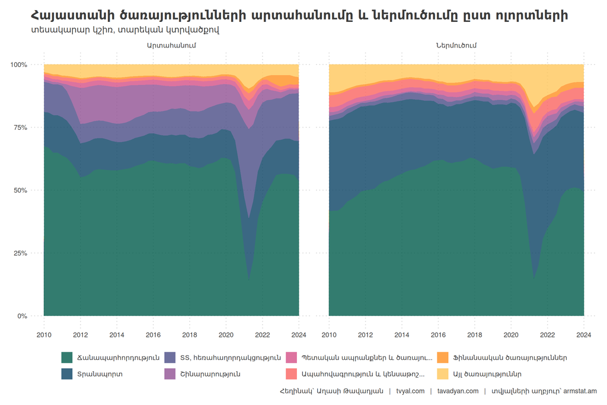

### Դիտարկենք նաև 2020 թվականի ծառայությունների արտահանման և ներմուծամն անկումը։

Կորոնավիրուսի համաճարակի բռնկումը մեծ ազդեցություն ունեցավ Հայաստանում ծառայությունների արտահանման և ներմուծման ցուցանիշների վրա։ 2020 թվականին ծառայությունների առևտրաշրջանառության զգալի անկում է գրանցվել, ընդ որում՝ ինչպես ներմուծման, այնպես էլ արտահանման ցուցանիշների։ 2020թ. ծառայությունների ներմուծումը նվազել էր 61,3%-ով՝ 2485 մլն ԱՄՆ դոլարից իջնելով 961 մլն ԱՄՆ դոլարի։ Ծառայությունների արտահանումը նվազել էր 55,9%-ով՝ 2402 մլն ԱՄՆ դոլարից հասնելով մինչև 1060 մլն ԱՄՆ դոլար։ Առևտրաշրջանառության էական նվազումը առաջին հերթին պայմանավորված է եղել զբոսաշրջային ծառայությունների արտահանման և ներմուծման կտրուկ կրճատմամբ։

Զբոսաշրջության ոլորտը, որը զգալիորեն նպաստում է ծառայությունների առևտրին, 2020 թվականին համավարակի պատճառով լուրջ հետընթաց ապրեց։ Գրանցվել է զբոսաշրջային ծառայությունների և՛ արտահանման, և՛ ներմուծման ծավալների զգալի անկում՝ արտահանումը 2020 թվականին նվազել է 82,0%-ով, իսկ ներմուծումը 84,5%-ով: Այս թվերը ընդգծում են ծառայությունների առևտրի ոլորտի մեծ կախվածությունը զբոսաշրջությունից: Ծառայությունների առևտրաշրջանառության անկման մեկ այլ ուշագրավ կողմը տրանսպորտային ծառայությունների ներմուծման կրճատումն էր: 2020 թվականին գրանցվեց 36.3% անկում:

**Գծապատկեր 3.**

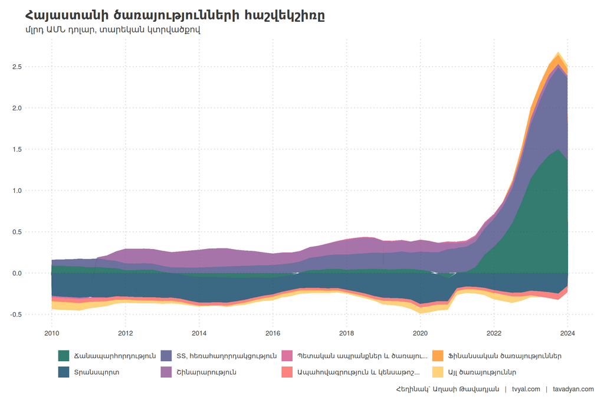

> Ձեզ կարող է հետաքրքրել նաև հետևյալ վերլուծությունը.

> [💸🔚🏦 Կապիտալի արտահոսք](https://www.tvyal.com/newsletter/2024/2024_03_01)։

2022 թվականին ծառայությունների արտահանումը կազմել է 4,2 մլրդ դոլար՝ զբոսաշրջային ծառայություններ՝ 58,4%, տեղեկատվական տեխնոլոգիաներ՝ 17,0%, տրանսպորտային ծառայություններ՝ 13,4%, շինարարական ծառայություններ՝ 2,5%։ 2021 թվականին ծառայությունների արտահանումը կազմել է 1,7 մլրդ դոլար՝ զբոսաշրջային ծառայություններ՝ 45,2%, տեղեկատվական տեխնոլոգիաներ՝ 22,0%, տրանսպորտային ծառայություններ՝ 17,5%, շինարարական ծառայություններ՝ 5,0%։

Ինչպես երևում է երրորդ գծապատկերից Հայաստանը ավելի շատ ներմուծում` տրանսպորտային ծառայություններ քան արտահանում: Տրանսպորտային ծառայությունների հաշվեկշիռը Հայաստանում պակասուրդային է: Այս ցուցանիշը կոռելացված է ապրանքների ներմուծման և արտահանման հետ:

## PODCAST !!

### Խոսենք թվերով #5

[Ինչքա՞ն հայ կունենանք Հայաստանում 2100 թվականին](https://www.youtube.com/watch?v=-IOVtoBD5gE)

- 🔘 Ինչքա՞ն է Հայաստանի բնակչությունը և ինչպե՞ս է փոխվում վերջին տարիներին
- 🔘 Ի՞նչ է լինելու արցախահայերի, ռուսների և հնդիկների գալով
- 🔘 Ինչպիսի՞ն է Հայաստանի բնակչության սեռատարիքային կազմը
- 🔘 Ինչքա՞ն հայ կունենանք առաջիկայում

How2B-ում «խոսում ենք թվերով»՝ տնտեսագետ Աղասի Թավադյանի հետ:

- 00:00 Ժողովրդագրական ընդհանուր իրավիճակը Հայաստանում
- 01։53 Դեմոգրաֆիկ փուլերն աշխարհում վերջին 100 տարիներին
- 03։06 Հայաստանի բնակչության փոփոխությունը վերջին 30 տարիներին
- 06:57 Հայաստան են եկել ռուսներ, արցախահայեր, հնդիկներ․ Ինչպե՞ս է փոխվում իրավիճակը
- 10:44 Մենք էլ ենք դառնում ծերացող ազգ
- 12։22 Կանայք Հայաստանում ավելի շատ են, թեև աղջիկ երեխաներ ավելի քիչ են ծնվում
- 17։55 Ամփոփում ենք

Թեմայով վերլուծությունը ներկայացված է tvyal.com կայքում՝ [👫🧭💀 Հայաստանում 2 մլն հայ 2100 թվականին](https://www.tvyal.com/newsletter/2024/2024_04_19)

[figure not shown]

## ԶԼՄ հաղորդագրություն

[Դիտեք Civilnet2-ին տված իմ վերջին հարցազրույցը, որտեղ խոսում եմ 2024 թվականի տնտեսական մարտահրավերների մասին։](https://youtu.be/3HyOvSfikwo)

📺 Ոսկու տենդը Հայաստանում թափ է հավաքում. Աղասի Թավադյան 📺

[figure not shown]

## English Summary

The analysis of quarterly data from Armenia’s balance of payments reveals fluctuations in the country’s service trade turnover, particularly in the export and import of tourism services. Following a significant decline in 2020 due to the COVID-19 pandemic, there was a gradual recovery in 2021 and 2022, with notable growth in tourism and IT services. However, since the fourth quarter of 2023, both imports and exports of services have experienced a contraction. Despite a slight increase in financial services, the overall trend indicates a decline in service trade, raising concerns regarding Armenia’s economic growth targets. The heavy reliance on tourism services is evident from the substantial decrease in both export and import volumes in 2020, emphasizing the vulnerability of the service trade sector to external shocks such as pandemics.

Այս վերլուծությունը առկա է նաև [մեր կայքէջում](https://www.tvyal.com/newsletter/2024/2024_04_26), այս վերլուծության կոդը և տվյալները դրված են նաև [Github-ում](https://github.com/tavad/tvyal_newsletter)։

Եթե հնարավոր է, խնդրում եմ այս նյութը ուղարկել նաև այն մարդկանց, ում այն կարծում եք կարող է հետաքրքրել:

Սպասեք հաջորդ հաղորդագրությանը հաջորդ ուրբաթ օրը:

Հարգանքներով,  
Աղասի Թավադյան  
26.04.2024  
[tvyal.com](https://www.tvyal.com/)  
[tavadyan.com](https://www.tavadyan.com/)

[Was this email forwarded to you? Subscribe here.](https://www.tvyal.com/subscribe)

[Բաժանորդագրվեք](https://www.tvyal.com/subscribe)

**Ուշադրություն. Ձեր էլ.փոստը մեյլլիսթի մեջ է, որի միջոցով ես կիսվում եմ շաբաթական նյութեր, որոնք հիմնականում ներկայացնում են Հայաստանի տնտեսությունը: Նյութերը ներառում են գծապատկերներ, [տվյալների բազաներ](https://github.com/tavad/tvyal_newsletter), տեսանյութեր, հոդվածներ, [առցանց վահանակներ](https://www.tvyal.com/projects), տնտեսական գործիքներ, կանխատեսումներ և հաշվետվություններ: Եթե ցանկանում եք չեղարկել բաժանորդագրությունը, խնդրում եմ տեղեկացրեք ինձ, և ես կհեռացնեմ ձեր էլ. փոստը ցուցակից: Գրեք նաև եթե ունեք մենկնաբանություններ:**

**Important! Your email is part of the mailing list where I share weekly materials primarily focused on the Armenian economy. These materials encompass charts, [databases](https://github.com/tavad/tvyal_newsletter), videos, articles, [online dashboards](https://www.tvyal.com/projects), economic tools, forecasts, and reports. If you wish to unsubscribe, please let me know, and I will remove your email from the list. Please share your comments as well․**